# Risk Factor Analysis

## Outcome Variable

**Outcome Variable:** stunted

## Predictor Variables

**Intervention Variable:** fage

**Adjustment Set:**

unadjusted

## Stratifying Variables

The analysis was stratified on these variable(s):

- agecat
- studyid
- country

## Data Summary

| agecat | studyid | country | fage | stunted | n_cell | n |
| --- | --- | --- | --- | --- | --- | --- |
| Birth | ki0047075b-MAL-ED | BANGLADESH | >=35 | 0 | 83 | 145 |
| Birth | ki0047075b-MAL-ED | BANGLADESH | >=35 | 1 | 16 | 145 |
| Birth | ki0047075b-MAL-ED | BANGLADESH | [25-30) | 0 | 11 | 145 |
| Birth | ki0047075b-MAL-ED | BANGLADESH | [25-30) | 1 | 2 | 145 |
| Birth | ki0047075b-MAL-ED | BANGLADESH | [30-35) | 0 | 31 | 145 |
| Birth | ki0047075b-MAL-ED | BANGLADESH | [30-35) | 1 | 2 | 145 |
| 6 months | ki0047075b-MAL-ED | BANGLADESH | >=35 | 0 | 83 | 150 |
| 6 months | ki0047075b-MAL-ED | BANGLADESH | >=35 | 1 | 18 | 150 |
| 6 months | ki0047075b-MAL-ED | BANGLADESH | [25-30) | 0 | 9 | 150 |
| 6 months | ki0047075b-MAL-ED | BANGLADESH | [25-30) | 1 | 5 | 150 |
| 6 months | ki0047075b-MAL-ED | BANGLADESH | [30-35) | 0 | 28 | 150 |
| 6 months | ki0047075b-MAL-ED | BANGLADESH | [30-35) | 1 | 7 | 150 |
| 24 months | ki0047075b-MAL-ED | BANGLADESH | >=35 | 0 | 59 | 151 |
| 24 months | ki0047075b-MAL-ED | BANGLADESH | >=35 | 1 | 43 | 151 |
| 24 months | ki0047075b-MAL-ED | BANGLADESH | [25-30) | 0 | 7 | 151 |
| 24 months | ki0047075b-MAL-ED | BANGLADESH | [25-30) | 1 | 7 | 151 |
| 24 months | ki0047075b-MAL-ED | BANGLADESH | [30-35) | 0 | 16 | 151 |
| 24 months | ki0047075b-MAL-ED | BANGLADESH | [30-35) | 1 | 19 | 151 |
| Birth | ki0047075b-MAL-ED | BRAZIL | >=35 | 0 | 31 | 68 |
| Birth | ki0047075b-MAL-ED | BRAZIL | >=35 | 1 | 4 | 68 |
| Birth | ki0047075b-MAL-ED | BRAZIL | <25 | 0 | 3 | 68 |
| Birth | ki0047075b-MAL-ED | BRAZIL | <25 | 1 | 0 | 68 |
| Birth | ki0047075b-MAL-ED | BRAZIL | [25-30) | 0 | 7 | 68 |
| Birth | ki0047075b-MAL-ED | BRAZIL | [25-30) | 1 | 0 | 68 |
| Birth | ki0047075b-MAL-ED | BRAZIL | [30-35) | 0 | 20 | 68 |
| Birth | ki0047075b-MAL-ED | BRAZIL | [30-35) | 1 | 3 | 68 |
| 6 months | ki0047075b-MAL-ED | BRAZIL | >=35 | 0 | 40 | 79 |
| 6 months | ki0047075b-MAL-ED | BRAZIL | <25 | 0 | 3 | 79 |
| 6 months | ki0047075b-MAL-ED | BRAZIL | [25-30) | 0 | 8 | 79 |
| 6 months | ki0047075b-MAL-ED | BRAZIL | [30-35) | 0 | 28 | 79 |

[output cut: 234 more lines]

The following strata were considered:

- agecat: 24 months, studyid: ki0047075b-MAL-ED, country: BANGLADESH
- agecat: 24 months, studyid: ki0047075b-MAL-ED, country: BRAZIL
- agecat: 24 months, studyid: ki0047075b-MAL-ED, country: INDIA
- agecat: 24 months, studyid: ki0047075b-MAL-ED, country: NEPAL
- agecat: 24 months, studyid: ki0047075b-MAL-ED, country: PERU
- agecat: 24 months, studyid: ki0047075b-MAL-ED, country: SOUTH AFRICA
- agecat: 24 months, studyid: ki0047075b-MAL-ED, country: TANZANIA, UNITED REPUBLIC OF
- agecat: 24 months, studyid: ki1119695-PROBIT, country: BELARUS
- agecat: 24 months, studyid: ki1135781-COHORTS, country: GUATEMALA
- agecat: 24 months, studyid: ki1135781-COHORTS, country: PHILIPPINES
- agecat: 24 months, studyid: ki1148112-LCNI-5, country: MALAWI
- agecat: 6 months, studyid: ki0047075b-MAL-ED, country: BANGLADESH
- agecat: 6 months, studyid: ki0047075b-MAL-ED, country: BRAZIL
- agecat: 6 months, studyid: ki0047075b-MAL-ED, country: INDIA
- agecat: 6 months, studyid: ki0047075b-MAL-ED, country: NEPAL
- agecat: 6 months, studyid: ki0047075b-MAL-ED, country: PERU
- agecat: 6 months, studyid: ki0047075b-MAL-ED, country: SOUTH AFRICA
- agecat: 6 months, studyid: ki0047075b-MAL-ED, country: TANZANIA, UNITED REPUBLIC OF
- agecat: 6 months, studyid: ki1000304b-SAS-CompFeed, country: INDIA
- agecat: 6 months, studyid: ki1000304b-SAS-FoodSuppl, country: INDIA
- agecat: 6 months, studyid: ki1119695-PROBIT, country: BELARUS
- agecat: 6 months, studyid: ki1135781-COHORTS, country: GUATEMALA
- agecat: 6 months, studyid: ki1135781-COHORTS, country: PHILIPPINES
- agecat: 6 months, studyid: ki1148112-LCNI-5, country: MALAWI
- agecat: Birth, studyid: ki0047075b-MAL-ED, country: BANGLADESH
- agecat: Birth, studyid: ki0047075b-MAL-ED, country: BRAZIL
- agecat: Birth, studyid: ki0047075b-MAL-ED, country: INDIA
- agecat: Birth, studyid: ki0047075b-MAL-ED, country: NEPAL
- agecat: Birth, studyid: ki0047075b-MAL-ED, country: PERU
- agecat: Birth, studyid: ki0047075b-MAL-ED, country: SOUTH AFRICA
- agecat: Birth, studyid: ki0047075b-MAL-ED, country: TANZANIA, UNITED REPUBLIC OF
- agecat: Birth, studyid: ki1000304b-SAS-CompFeed, country: INDIA
- agecat: Birth, studyid: ki1119695-PROBIT, country: BELARUS
- agecat: Birth, studyid: ki1135781-COHORTS, country: GUATEMALA
- agecat: Birth, studyid: ki1135781-COHORTS, country: PHILIPPINES

### Dropped Strata

Some strata were dropped due to rare outcomes:

- agecat: Birth, studyid: ki0047075b-MAL-ED, country: BANGLADESH
- agecat: Birth, studyid: ki0047075b-MAL-ED, country: BRAZIL
- agecat: 6 months, studyid: ki0047075b-MAL-ED, country: BRAZIL
- agecat: 24 months, studyid: ki0047075b-MAL-ED, country: BRAZIL
- agecat: Birth, studyid: ki0047075b-MAL-ED, country: INDIA
- agecat: 6 months, studyid: ki0047075b-MAL-ED, country: INDIA
- agecat: 24 months, studyid: ki0047075b-MAL-ED, country: INDIA
- agecat: Birth, studyid: ki0047075b-MAL-ED, country: NEPAL
- agecat: 6 months, studyid: ki0047075b-MAL-ED, country: NEPAL
- agecat: 24 months, studyid: ki0047075b-MAL-ED, country: NEPAL
- agecat: Birth, studyid: ki0047075b-MAL-ED, country: PERU
- agecat: 6 months, studyid: ki0047075b-MAL-ED, country: PERU
- agecat: 24 months, studyid: ki0047075b-MAL-ED, country: PERU
- agecat: Birth, studyid: ki0047075b-MAL-ED, country: SOUTH AFRICA
- agecat: 6 months, studyid: ki0047075b-MAL-ED, country: SOUTH AFRICA
- agecat: 24 months, studyid: ki0047075b-MAL-ED, country: SOUTH AFRICA
- agecat: Birth, studyid: ki0047075b-MAL-ED, country: TANZANIA, UNITED REPUBLIC OF
- agecat: 6 months, studyid: ki0047075b-MAL-ED, country: TANZANIA, UNITED REPUBLIC OF
- agecat: 24 months, studyid: ki0047075b-MAL-ED, country: TANZANIA, UNITED REPUBLIC OF
- agecat: Birth, studyid: ki1000304b-SAS-CompFeed, country: INDIA
- agecat: Birth, studyid: ki1119695-PROBIT, country: BELARUS
- agecat: 24 months, studyid: ki1148112-LCNI-5, country: MALAWI

## Methods Detail

We’re interested in the causal parameters $E[Y_a]$ for all values of $a \in \mathcal{A}$. These parameters represent the mean outcome if, possibly contrary to fact, we intervened to set all units to have $A=a$. Under the randomization and positivity assumptions, these are identified by the statistical parameters $\psi_a=E_W[E_{Y|A,W}(Y|A=a,W)]$. In addition, we’re interested in the mean of $Y$, $E[Y]$ under no intervention (the observed mean). We will estimate these parameters by using SuperLearner to fit the relevant likelihood factors – $E_{Y|A,W}(Y|A=a,W)$ and $p(A=a|W)$, and then updating our likelihood fit using a joint TMLE.

For unadjusted analyses ($W=\{\}$), initial likelihoods were estimated using Lrnr_glm to estimate the simple $E(Y|A)$ and Lrnr_mean to estimate $p(A)$. For adjusted analyses, a small library containing Lrnr_glmnet, Lrnr_xgboost, and Lrnr_mean was used.

Having estimated these parameters, we will then use the delta method to estimate relative risks and attributable risks relative to a prespecified baseline level of $A$.

# Results Detail

## Results Plots

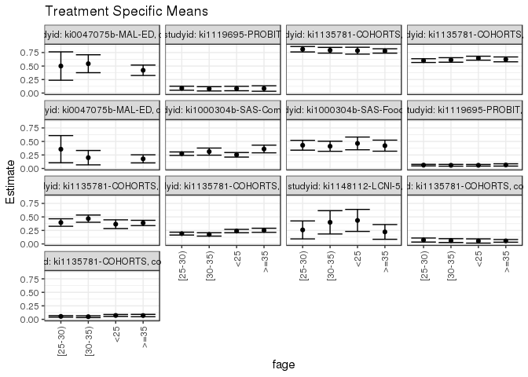

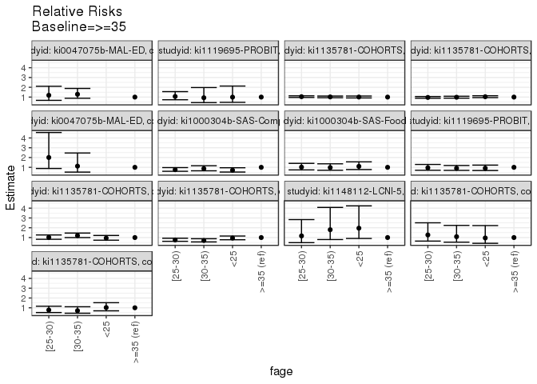

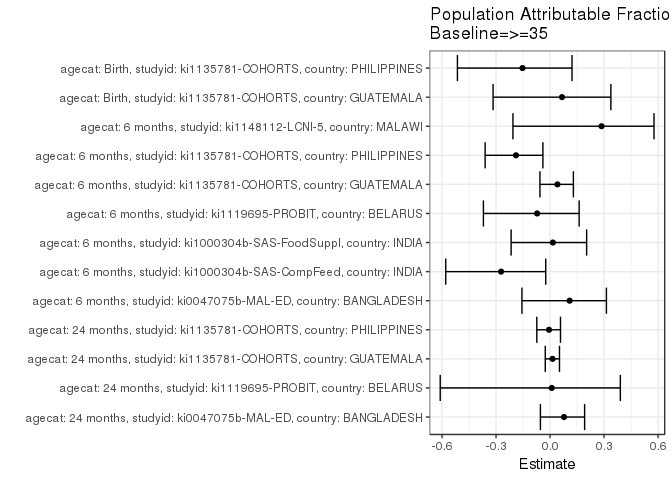

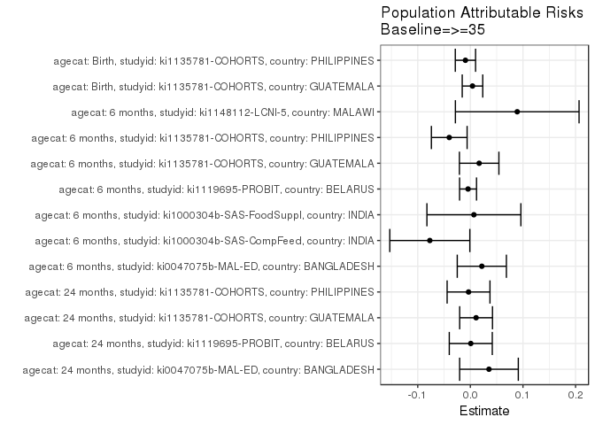

## Results Table

### Parameter: TSM

| agecat | studyid | country | intervention_level | baseline_level | estimate | ci_lower | ci_upper |
| --- | --- | --- | --- | --- | --- | --- | --- |
| Birth | ki1135781-COHORTS | GUATEMALA | >=35 | NA | 0.0567164 | 0.0319328 | 0.0815001 |
| Birth | ki1135781-COHORTS | GUATEMALA | <25 | NA | 0.0542636 | 0.0151474 | 0.0933797 |
| Birth | ki1135781-COHORTS | GUATEMALA | [25-30) | NA | 0.0718232 | 0.0341857 | 0.1094607 |
| Birth | ki1135781-COHORTS | GUATEMALA | [30-35) | NA | 0.0617978 | 0.0264032 | 0.0971923 |
| Birth | ki1135781-COHORTS | PHILIPPINES | >=35 | NA | 0.0705009 | 0.0488862 | 0.0921156 |
| Birth | ki1135781-COHORTS | PHILIPPINES | <25 | NA | 0.0721393 | 0.0542530 | 0.0900256 |
| Birth | ki1135781-COHORTS | PHILIPPINES | [25-30) | NA | 0.0545073 | 0.0400993 | 0.0689154 |
| Birth | ki1135781-COHORTS | PHILIPPINES | [30-35) | NA | 0.0494590 | 0.0327490 | 0.0661691 |
| 6 months | ki0047075b-MAL-ED | BANGLADESH | >=35 | NA | 0.1782178 | 0.1033330 | 0.2531026 |
| 6 months | ki0047075b-MAL-ED | BANGLADESH | [25-30) | NA | 0.3571429 | 0.1053086 | 0.6089771 |
| 6 months | ki0047075b-MAL-ED | BANGLADESH | [30-35) | NA | 0.2000000 | 0.0670383 | 0.3329617 |
| 6 months | ki1000304b-SAS-CompFeed | INDIA | >=35 | NA | 0.3606557 | 0.2897206 | 0.4315909 |
| 6 months | ki1000304b-SAS-CompFeed | INDIA | <25 | NA | 0.2531646 | 0.2109382 | 0.2953909 |
| 6 months | ki1000304b-SAS-CompFeed | INDIA | [25-30) | NA | 0.2742230 | 0.2426029 | 0.3058432 |
| 6 months | ki1000304b-SAS-CompFeed | INDIA | [30-35) | NA | 0.3122677 | 0.2462228 | 0.3783125 |
| 6 months | ki1000304b-SAS-FoodSuppl | INDIA | >=35 | NA | 0.4222222 | 0.3200460 | 0.5243985 |
| 6 months | ki1000304b-SAS-FoodSuppl | INDIA | <25 | NA | 0.4637681 | 0.3459472 | 0.5815891 |
| 6 months | ki1000304b-SAS-FoodSuppl | INDIA | [25-30) | NA | 0.4298246 | 0.3388295 | 0.5208196 |
| 6 months | ki1000304b-SAS-FoodSuppl | INDIA | [30-35) | NA | 0.4112150 | 0.3178592 | 0.5045707 |
| 6 months | ki1119695-PROBIT | BELARUS | >=35 | NA | 0.0655738 | 0.0442644 | 0.0868831 |
| 6 months | ki1119695-PROBIT | BELARUS | <25 | NA | 0.0596312 | 0.0443241 | 0.0749384 |
| 6 months | ki1119695-PROBIT | BELARUS | [25-30) | NA | 0.0623573 | 0.0481129 | 0.0766017 |
| 6 months | ki1119695-PROBIT | BELARUS | [30-35) | NA | 0.0592954 | 0.0429924 | 0.0755985 |
| 6 months | ki1135781-COHORTS | GUATEMALA | >=35 | NA | 0.3880208 | 0.3392554 | 0.4367863 |
| 6 months | ki1135781-COHORTS | GUATEMALA | <25 | NA | 0.3649635 | 0.2843058 | 0.4456212 |
| 6 months | ki1135781-COHORTS | GUATEMALA | [25-30) | NA | 0.3958333 | 0.3266238 | 0.4650429 |
| 6 months | ki1135781-COHORTS | GUATEMALA | [30-35) | NA | 0.4675926 | 0.4010176 | 0.5341676 |
| 6 months | ki1135781-COHORTS | PHILIPPINES | >=35 | NA | 0.2520161 | 0.2137997 | 0.2902326 |
| 6 months | ki1135781-COHORTS | PHILIPPINES | <25 | NA | 0.2380952 | 0.2068483 | 0.2693422 |
| 6 months | ki1135781-COHORTS | PHILIPPINES | [25-30) | NA | 0.1906475 | 0.1639831 | 0.2173119 |
| 6 months | ki1135781-COHORTS | PHILIPPINES | [30-35) | NA | 0.1758621 | 0.1448734 | 0.2068507 |
| 6 months | ki1148112-LCNI-5 | MALAWI | >=35 | NA | 0.2222222 | 0.0857713 | 0.3586732 |
| 6 months | ki1148112-LCNI-5 | MALAWI | <25 | NA | 0.4347826 | 0.2312255 | 0.6383397 |
| 6 months | ki1148112-LCNI-5 | MALAWI | [25-30) | NA | 0.2592593 | 0.0931764 | 0.4253421 |
| 6 months | ki1148112-LCNI-5 | MALAWI | [30-35) | NA | 0.4000000 | 0.1842767 | 0.6157233 |
| 24 months | ki0047075b-MAL-ED | BANGLADESH | >=35 | NA | 0.4215686 | 0.3254183 | 0.5177190 |
| 24 months | ki0047075b-MAL-ED | BANGLADESH | [25-30) | NA | 0.5000000 | 0.2372172 | 0.7627828 |
| 24 months | ki0047075b-MAL-ED | BANGLADESH | [30-35) | NA | 0.5428571 | 0.3772704 | 0.7084439 |
| 24 months | ki1119695-PROBIT | BELARUS | >=35 | NA | 0.0841346 | 0.0336840 | 0.1345852 |
| 24 months | ki1119695-PROBIT | BELARUS | <25 | NA | 0.0835987 | 0.0427711 | 0.1244264 |
| 24 months | ki1119695-PROBIT | BELARUS | [25-30) | NA | 0.0894526 | 0.0521272 | 0.1267781 |
| 24 months | ki1119695-PROBIT | BELARUS | [30-35) | NA | 0.0784844 | 0.0387508 | 0.1182181 |
| 24 months | ki1135781-COHORTS | GUATEMALA | >=35 | NA | 0.7791563 | 0.7386370 | 0.8196757 |
| 24 months | ki1135781-COHORTS | GUATEMALA | <25 | NA | 0.7839506 | 0.7205456 | 0.8473556 |
| 24 months | ki1135781-COHORTS | GUATEMALA | [25-30) | NA | 0.8111588 | 0.7608801 | 0.8614374 |
| 24 months | ki1135781-COHORTS | GUATEMALA | [30-35) | NA | 0.7920354 | 0.7390967 | 0.8449741 |
| 24 months | ki1135781-COHORTS | PHILIPPINES | >=35 | NA | 0.6230248 | 0.5778864 | 0.6681633 |
| 24 months | ki1135781-COHORTS | PHILIPPINES | <25 | NA | 0.6450617 | 0.6082124 | 0.6819110 |
| 24 months | ki1135781-COHORTS | PHILIPPINES | [25-30) | NA | 0.6005256 | 0.5657193 | 0.6353319 |
| 24 months | ki1135781-COHORTS | PHILIPPINES | [30-35) | NA | 0.6127168 | 0.5707988 | 0.6546347 |

### Parameter: E(Y)

| agecat | studyid | country | intervention_level | baseline_level | estimate | ci_lower | ci_upper |
| --- | --- | --- | --- | --- | --- | --- | --- |
| Birth | ki1135781-COHORTS | GUATEMALA | NA | NA | 0.0607533 | 0.0444233 | 0.0770834 |
| Birth | ki1135781-COHORTS | PHILIPPINES | NA | NA | 0.0611413 | 0.0524852 | 0.0697974 |
| 6 months | ki0047075b-MAL-ED | BANGLADESH | NA | NA | 0.2000000 | 0.1357734 | 0.2642266 |
| 6 months | ki1000304b-SAS-CompFeed | INDIA | NA | NA | 0.2835709 | 0.2656121 | 0.3015297 |
| 6 months | ki1000304b-SAS-FoodSuppl | INDIA | NA | NA | 0.4289474 | 0.3791199 | 0.4787748 |
| 6 months | ki1119695-PROBIT | BELARUS | NA | NA | 0.0611869 | 0.0477477 | 0.0746260 |
| 6 months | ki1135781-COHORTS | GUATEMALA | NA | NA | 0.4047363 | 0.3731561 | 0.4363165 |
| 6 months | ki1135781-COHORTS | PHILIPPINES | NA | NA | 0.2118902 | 0.1962516 | 0.2275288 |
| 6 months | ki1148112-LCNI-5 | MALAWI | NA | NA | 0.3113208 | 0.2227550 | 0.3998865 |
| 24 months | ki0047075b-MAL-ED | BANGLADESH | NA | NA | 0.4569536 | 0.3772355 | 0.5366718 |
| 24 months | ki1119695-PROBIT | BELARUS | NA | NA | 0.0849322 | 0.0549995 | 0.1148649 |
| 24 months | ki1135781-COHORTS | GUATEMALA | NA | NA | 0.7900391 | 0.7650814 | 0.8149967 |
| 24 months | ki1135781-COHORTS | PHILIPPINES | NA | NA | 0.6195698 | 0.6000239 | 0.6391157 |

### Parameter: RR

| agecat | studyid | country | intervention_level | baseline_level | estimate | ci_lower | ci_upper |
| --- | --- | --- | --- | --- | --- | --- | --- |
| Birth | ki1135781-COHORTS | GUATEMALA | >=35 | >=35 | 1.0000000 | 1.0000000 | 1.0000000 |
| Birth | ki1135781-COHORTS | GUATEMALA | <25 | >=35 | 0.9567523 | 0.4118198 | 2.2227564 |
| Birth | ki1135781-COHORTS | GUATEMALA | [25-30) | >=35 | 1.2663565 | 0.6400741 | 2.5054267 |
| Birth | ki1135781-COHORTS | GUATEMALA | [30-35) | >=35 | 1.0895920 | 0.5301449 | 2.2394077 |
| Birth | ki1135781-COHORTS | PHILIPPINES | >=35 | >=35 | 1.0000000 | 1.0000000 | 1.0000000 |
| Birth | ki1135781-COHORTS | PHILIPPINES | <25 | >=35 | 1.0232391 | 0.6898198 | 1.5178141 |
| Birth | ki1135781-COHORTS | PHILIPPINES | [25-30) | >=35 | 0.7731436 | 0.5157693 | 1.1589502 |
| Birth | ki1135781-COHORTS | PHILIPPINES | [30-35) | >=35 | 0.7015375 | 0.4445433 | 1.1071021 |
| 6 months | ki0047075b-MAL-ED | BANGLADESH | >=35 | >=35 | 1.0000000 | 1.0000000 | 1.0000000 |
| 6 months | ki0047075b-MAL-ED | BANGLADESH | [25-30) | >=35 | 2.0039683 | 0.8818724 | 4.5538207 |
| 6 months | ki0047075b-MAL-ED | BANGLADESH | [30-35) | >=35 | 1.1222222 | 0.5111182 | 2.4639754 |
| 6 months | ki1000304b-SAS-CompFeed | INDIA | >=35 | >=35 | 1.0000000 | 1.0000000 | 1.0000000 |
| 6 months | ki1000304b-SAS-CompFeed | INDIA | <25 | >=35 | 0.7019563 | 0.5167559 | 0.9535307 |
| 6 months | ki1000304b-SAS-CompFeed | INDIA | [25-30) | >=35 | 0.7603457 | 0.5958781 | 0.9702078 |
| 6 months | ki1000304b-SAS-CompFeed | INDIA | [30-35) | >=35 | 0.8658331 | 0.6456315 | 1.1611373 |
| 6 months | ki1000304b-SAS-FoodSuppl | INDIA | >=35 | >=35 | 1.0000000 | 1.0000000 | 1.0000000 |
| 6 months | ki1000304b-SAS-FoodSuppl | INDIA | <25 | >=35 | 1.0983982 | 0.7733609 | 1.5600459 |
| 6 months | ki1000304b-SAS-FoodSuppl | INDIA | [25-30) | >=35 | 1.0180055 | 0.7380950 | 1.4040676 |
| 6 months | ki1000304b-SAS-FoodSuppl | INDIA | [30-35) | >=35 | 0.9739302 | 0.6989107 | 1.3571691 |
| 6 months | ki1119695-PROBIT | BELARUS | >=35 | >=35 | 1.0000000 | 1.0000000 | 1.0000000 |
| 6 months | ki1119695-PROBIT | BELARUS | <25 | >=35 | 0.9093762 | 0.6750939 | 1.2249631 |
| 6 months | ki1119695-PROBIT | BELARUS | [25-30) | >=35 | 0.9509485 | 0.6999002 | 1.2920459 |
| 6 months | ki1119695-PROBIT | BELARUS | [30-35) | >=35 | 0.9042553 | 0.6865399 | 1.1910125 |
| 6 months | ki1135781-COHORTS | GUATEMALA | >=35 | >=35 | 1.0000000 | 1.0000000 | 1.0000000 |
| 6 months | ki1135781-COHORTS | GUATEMALA | <25 | >=35 | 0.9405771 | 0.7294247 | 1.2128535 |
| 6 months | ki1135781-COHORTS | GUATEMALA | [25-30) | >=35 | 1.0201342 | 0.8225117 | 1.2652390 |
| 6 months | ki1135781-COHORTS | GUATEMALA | [30-35) | >=35 | 1.2050708 | 0.9966326 | 1.4571023 |
| 6 months | ki1135781-COHORTS | PHILIPPINES | >=35 | >=35 | 1.0000000 | 1.0000000 | 1.0000000 |
| 6 months | ki1135781-COHORTS | PHILIPPINES | <25 | >=35 | 0.9447619 | 0.7730833 | 1.1545651 |
| 6 months | ki1135781-COHORTS | PHILIPPINES | [25-30) | >=35 | 0.7564892 | 0.6154752 | 0.9298115 |
| 6 months | ki1135781-COHORTS | PHILIPPINES | [30-35) | >=35 | 0.6978207 | 0.5530703 | 0.8804553 |
| 6 months | ki1148112-LCNI-5 | MALAWI | >=35 | >=35 | 1.0000000 | 1.0000000 | 1.0000000 |
| 6 months | ki1148112-LCNI-5 | MALAWI | <25 | >=35 | 1.9565217 | 0.9039436 | 4.2347526 |
| 6 months | ki1148112-LCNI-5 | MALAWI | [25-30) | >=35 | 1.1666667 | 0.4803650 | 2.8334932 |
| 6 months | ki1148112-LCNI-5 | MALAWI | [30-35) | >=35 | 1.8000000 | 0.7949660 | 4.0756458 |
| 24 months | ki0047075b-MAL-ED | BANGLADESH | >=35 | >=35 | 1.0000000 | 1.0000000 | 1.0000000 |
| 24 months | ki0047075b-MAL-ED | BANGLADESH | [25-30) | >=35 | 1.1860465 | 0.6687830 | 2.1033822 |
| 24 months | ki0047075b-MAL-ED | BANGLADESH | [30-35) | >=35 | 1.2877076 | 0.8798481 | 1.8846332 |
| 24 months | ki1119695-PROBIT | BELARUS | >=35 | >=35 | 1.0000000 | 1.0000000 | 1.0000000 |
| 24 months | ki1119695-PROBIT | BELARUS | <25 | >=35 | 0.9936306 | 0.4644267 | 2.1258503 |
| 24 months | ki1119695-PROBIT | BELARUS | [25-30) | >=35 | 1.0632081 | 0.7261014 | 1.5568230 |
| 24 months | ki1119695-PROBIT | BELARUS | [30-35) | >=35 | 0.9328436 | 0.4405351 | 1.9753185 |
| 24 months | ki1135781-COHORTS | GUATEMALA | >=35 | >=35 | 1.0000000 | 1.0000000 | 1.0000000 |
| 24 months | ki1135781-COHORTS | GUATEMALA | <25 | >=35 | 1.0061532 | 0.9139121 | 1.1077041 |
| 24 months | ki1135781-COHORTS | GUATEMALA | [25-30) | >=35 | 1.0410732 | 0.9601577 | 1.1288078 |
| 24 months | ki1135781-COHORTS | GUATEMALA | [30-35) | >=35 | 1.0165295 | 0.9339873 | 1.1063664 |
| 24 months | ki1135781-COHORTS | PHILIPPINES | >=35 | >=35 | 1.0000000 | 1.0000000 | 1.0000000 |
| 24 months | ki1135781-COHORTS | PHILIPPINES | <25 | >=35 | 1.0353708 | 0.9441192 | 1.1354422 |
| 24 months | ki1135781-COHORTS | PHILIPPINES | [25-30) | >=35 | 0.9638871 | 0.8784796 | 1.0575981 |
| 24 months | ki1135781-COHORTS | PHILIPPINES | [30-35) | >=35 | 0.9834548 | 0.8901812 | 1.0865017 |

### Parameter: PAR

| agecat | studyid | country | intervention_level | baseline_level | estimate | ci_lower | ci_upper |
| --- | --- | --- | --- | --- | --- | --- | --- |
| Birth | ki1135781-COHORTS | GUATEMALA | >=35 | NA | 0.0040369 | -0.0154787 | 0.0235525 |
| Birth | ki1135781-COHORTS | PHILIPPINES | >=35 | NA | -0.0093596 | -0.0286223 | 0.0099031 |
| 6 months | ki0047075b-MAL-ED | BANGLADESH | >=35 | NA | 0.0217822 | -0.0249194 | 0.0684838 |
| 6 months | ki1000304b-SAS-CompFeed | INDIA | >=35 | NA | -0.0770848 | -0.1531822 | -0.0009875 |
| 6 months | ki1000304b-SAS-FoodSuppl | INDIA | >=35 | NA | 0.0067251 | -0.0825917 | 0.0960420 |
| 6 months | ki1119695-PROBIT | BELARUS | >=35 | NA | -0.0043869 | -0.0205015 | 0.0117276 |
| 6 months | ki1135781-COHORTS | GUATEMALA | >=35 | NA | 0.0167154 | -0.0208271 | 0.0542579 |
| 6 months | ki1135781-COHORTS | PHILIPPINES | >=35 | NA | -0.0401259 | -0.0740806 | -0.0061712 |
| 6 months | ki1148112-LCNI-5 | MALAWI | >=35 | NA | 0.0890985 | -0.0284429 | 0.2066400 |
| 24 months | ki0047075b-MAL-ED | BANGLADESH | >=35 | NA | 0.0353850 | -0.0203831 | 0.0911531 |
| 24 months | ki1119695-PROBIT | BELARUS | >=35 | NA | 0.0007976 | -0.0400691 | 0.0416643 |
| 24 months | ki1135781-COHORTS | GUATEMALA | >=35 | NA | 0.0108827 | -0.0203008 | 0.0420663 |
| 24 months | ki1135781-COHORTS | PHILIPPINES | >=35 | NA | -0.0034550 | -0.0441755 | 0.0372654 |

### Parameter: PAF

| agecat | studyid | country | intervention_level | baseline_level | estimate | ci_lower | ci_upper |
| --- | --- | --- | --- | --- | --- | --- | --- |
| Birth | ki1135781-COHORTS | GUATEMALA | >=35 | NA | 0.0664478 | -0.3163522 | 0.3379281 |
| Birth | ki1135781-COHORTS | PHILIPPINES | >=35 | NA | -0.1530818 | -0.5145436 | 0.1221133 |
| 6 months | ki0047075b-MAL-ED | BANGLADESH | >=35 | NA | 0.1089109 | -0.1561578 | 0.3132081 |
| 6 months | ki1000304b-SAS-CompFeed | INDIA | >=35 | NA | -0.2718362 | -0.5796006 | -0.0240357 |
| 6 months | ki1000304b-SAS-FoodSuppl | INDIA | >=35 | NA | 0.0156783 | -0.2162123 | 0.2033551 |
| 6 months | ki1119695-PROBIT | BELARUS | >=35 | NA | -0.0716970 | -0.3702063 | 0.1617798 |
| 6 months | ki1135781-COHORTS | GUATEMALA | >=35 | NA | 0.0412996 | -0.0561127 | 0.1297269 |
| 6 months | ki1135781-COHORTS | PHILIPPINES | >=35 | NA | -0.1893711 | -0.3606631 | -0.0396428 |
| 6 months | ki1148112-LCNI-5 | MALAWI | >=35 | NA | 0.2861953 | -0.2061228 | 0.5775578 |
| 24 months | ki0047075b-MAL-ED | BANGLADESH | >=35 | NA | 0.0774368 | -0.0535178 | 0.1921134 |
| 24 months | ki1119695-PROBIT | BELARUS | >=35 | NA | 0.0093909 | -0.6100702 | 0.3905195 |
| 24 months | ki1135781-COHORTS | GUATEMALA | >=35 | NA | 0.0137749 | -0.0265125 | 0.0524812 |
| 24 months | ki1135781-COHORTS | PHILIPPINES | >=35 | NA | -0.0055765 | -0.0734962 | 0.0580460 |